# Choosing between the three fitting regimes

```r
library(proxymix)
```

```r
has_ggplot2 <- requireNamespace("ggplot2", quietly = TRUE)
```

## The problem

proxymix fits a mixture of a few normal distributions, called a Gaussian mixture, as a stand-in, or proxy, for a distribution you want to work with. The distribution being approximated is called the target. The package has three ways of fitting the proxy, described by van der Hoek and Elliott (2024). They differ in what they need from the target: a sample drawn from it, or a formula for its density.

Often only one kind of input is available, and the choice is made for you. Sometimes you have both, and two of the methods will run on the same target and return similar-looking mixtures. This vignette runs all three methods on targets that have both a formula and a sample, and shows what each one uses and what it costs. It then checks the sample-based method against three established mixture packages.

## Package capabilities

- `fit_moment_match()` fits a single normal distribution with the same mean and covariance as the target’s sample. This is method (i).
- `fit_em_samples()` fits a mixture of several normal distributions to a sample. This is method (ii).
- `fit_kld_em()` fits a mixture to the density formula alone, without a sample. This is method (iii).
- `fit_proxymix()` runs any of the three. Its `regime` argument takes the values `"moment"`, `"sample"` and `"kld"`, or `"auto"` to choose from what the target carries.
- `bic_aic()` and `select_N()` choose the number of components. None of the three fitting methods chooses it for you.
- `mixture_target()` and `banana_target()` are ready-made targets in two variables. Each can carry a sample as well as its formula.

## Addressing the problem

### A target with both a formula and a sample

The ready-made mixture target is itself a mixture of three normal distributions. Its density formula is known exactly, and exact samples are easy to draw. All three methods can therefore be run on the same target.

```r
tgt <- mixture_target(with_samples = TRUE, n = 1500L, seed = 1L)
tgt
```

```
#> <gmm_target>: "three_mixture" in p = 2 dimensions
#>   log_density : supplied
#>   samples     : 1500 x 2 matrix
#>   normalised  : TRUE
#>   log Z(f)    : 0
```

### Method (i): one normal distribution with the sample’s mean and spread

With one component (`N = 1`), the closest normal distribution to the target has the same mean and covariance as the target. “Closest” here is measured by the Kullback-Leibler (KL) divergence, which is zero when two distributions match and grows as they differ. Method (i) computes the mean and covariance of the sample in one step, with no iteration.

```r
m_fit <- fit_proxymix(tgt, N = 1L, regime = "moment")
m_fit
```

```
#> <gmm_fit>: regime = "moment", K = 1, p = 2
#>   target     : three_mixture
#>   iterations : 0
#>   converged  : TRUE
#>   [1] w = 1.0000, |mu| = 0.0328, tr(Sigma) = 5.6029
```

The fitted mean and covariance equal those of the sample. The only difference is a small constant, set by `ridge_eps`, that is added to the diagonal of the covariance matrix, which stops the fit failing when the matrix is close to singular. With `ridge_eps = 0` the difference disappears.

```r
m_fit_bare <- fit_proxymix(tgt, N = 1L, regime = "moment", ridge_eps = 0)
moment_gap <- c(
  mean = max(abs(m_fit@means[[1L]] - colMeans(tgt@samples))),
  covariance = max(abs(m_fit@covariances[[1L]] - cov(tgt@samples))),
  covariance_no_ridge = max(abs(m_fit_bare@covariances[[1L]] -
                                  cov(tgt@samples)))
)
signif(moment_gap, 3L)
```

```
#>                mean          covariance covariance_no_ridge
#>               0e+00               1e-06               0e+00
```

One normal distribution cannot describe a target with three peaks. It is, however, the closest single normal distribution to the target.

### Method (ii): several normal distributions fitted to the sample

Method (ii) is the expectation-maximisation (EM) algorithm, the standard way to fit a mixture to a sample. Each round has two steps. The first step works out, for every point, the probability that it came from each component. The second step refits each component’s weight, mean and covariance to the points, counting each point in proportion to those probabilities. The same `ridge_eps` stops each covariance from becoming singular. The rounds stop when the log-likelihood of the sample, a measure of how well the mixture fits it, changes by less than the tolerance `tol`. `n_starts = 4L` runs the algorithm from four starting points and keeps the best fit.

```r
s_fit <- fit_proxymix(tgt, N = 3L, regime = "sample",
                      max_iter = 200L, n_starts = 4L, seed = 1L)
s_fit
```

```
#> <gmm_fit>: regime = "sample", K = 3, p = 2
#>   target     : three_mixture
#>   iterations : 17
#>   converged  : TRUE
#>   [1] w = 0.4061, |mu| = 0.0336, tr(Sigma) = 0.9343
#>   [2] w = 0.3032, |mu| = 2.7588, tr(Sigma) = 1.2155
#>   [3] w = 0.2907, |mu| = 2.8186, tr(Sigma) = 0.8084
```

### Method (iii): several normal distributions fitted to the formula

Method (iii) needs only the density formula. It is the method to use when no sample exists, as with a Bayesian posterior that comes as a formula with no direct way to draw from it. It draws trial points once from a broad distribution that is easy to sample, called the proposal. Each trial point is weighted by how much more likely it is under the target than under the proposal. The mixture is then refitted to the weighted points in rounds, which lower the KL divergence from the target. The proposal here is a Student-t distribution, a relative of the normal with heavier tails. Its degrees of freedom, `df = 5`, set how heavy the tails are: the fewer, the heavier.

```r
k_fit <- fit_proxymix(tgt, N = 3L, regime = "kld",
                      proposal = proposal_mvt(n_dim = 2L,
                                              mean = c(0, 0),
                                              sigma = 6 * diag(2),
                                              df = 5),
                      is_size = 3000L,
                      max_iter = 60L,
                      seed = 1L)
k_fit
```

```
#> <gmm_fit>: regime = "kld", K = 3, p = 2
#>   target     : three_mixture
#>   iterations : 10
#>   converged  : TRUE
#>   [1] w = 0.4164, |mu| = 0.0300, tr(Sigma) = 0.8377
#>   [2] w = 0.3069, |mu| = 2.7545, tr(Sigma) = 1.2249
#>   [3] w = 0.2767, |mu| = 2.7562, tr(Sigma) = 0.8740
```

### The three fits side by side

```r
grid_x <- seq(-4.5, 4.5, length.out = 100L)
grid_base <- expand.grid(x1 = grid_x, x2 = grid_x)
grid_mat <- as.matrix(grid_base)
target_d <- exp(tgt@log_density(grid_mat))
panel_of <- function(fit, label) {
  data.frame(
    x1 = grid_base$x1, x2 = grid_base$x2,
    target = target_d,
    proxy = dgmm(grid_mat, fit),
    regime = label,
    stringsAsFactors = FALSE
  )
}
overlay_df <- rbind(
  panel_of(m_fit, "(i) moment, N = 1"),
  panel_of(s_fit, "(ii) sample EM, N = 3"),
  panel_of(k_fit, "(iii) KLD-EM, N = 3")
)
overlay_df$regime <- factor(overlay_df$regime,
                            levels = unique(overlay_df$regime))
```

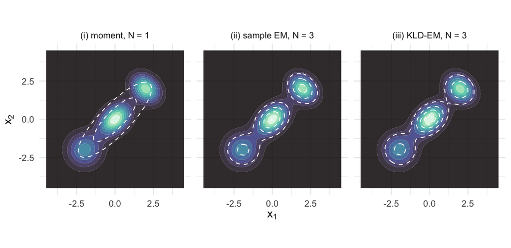

The three-peak target (filled contours, the same in all three panels) with each method’s proxy overlaid as dashed contours. Method (i) spreads one normal distribution across all three peaks. Methods (ii) and (iii) each place one component on each peak and look alike, although (ii) used only the sample and (iii) only the formula.

```r
ggplot2::ggplot(overlay_df, ggplot2::aes(x1, x2)) +
  ggplot2::geom_contour_filled(ggplot2::aes(z = target), bins = 10L,
                               alpha = 0.85) +
  ggplot2::geom_contour(ggplot2::aes(z = proxy), colour = "white",
                        linetype = "dashed", linewidth = 0.4, bins = 5L) +
  ggplot2::scale_fill_viridis_d(option = "mako", guide = "none") +
  ggplot2::facet_wrap(~ regime) +
  ggplot2::coord_equal() +
  ggplot2::labs(x = expression(x[1]), y = expression(x[2])) +
  ggplot2::theme_minimal(base_size = 11)
```

### What each method improves in each round

Methods (ii) and (iii) aim at different quantities. Method (ii) raises the log-likelihood of the sample. Method (iii) lowers an estimate of the KL divergence from the target, computed on the weighted trial points.

```r
trace_df <- rbind(
  data.frame(
    iteration = seq_along(s_fit@diagnostics$loglik_trace),
    value = s_fit@diagnostics$loglik_trace,
    panel = "(ii) sample EM: log-likelihood (up)",
    stringsAsFactors = FALSE
  ),
  data.frame(
    iteration = seq_along(kld_trace(k_fit)),
    value = kld_trace(k_fit),
    panel = "(iii) KLD-EM: KL on the fitting draws (down)",
    stringsAsFactors = FALSE
  )
)
```

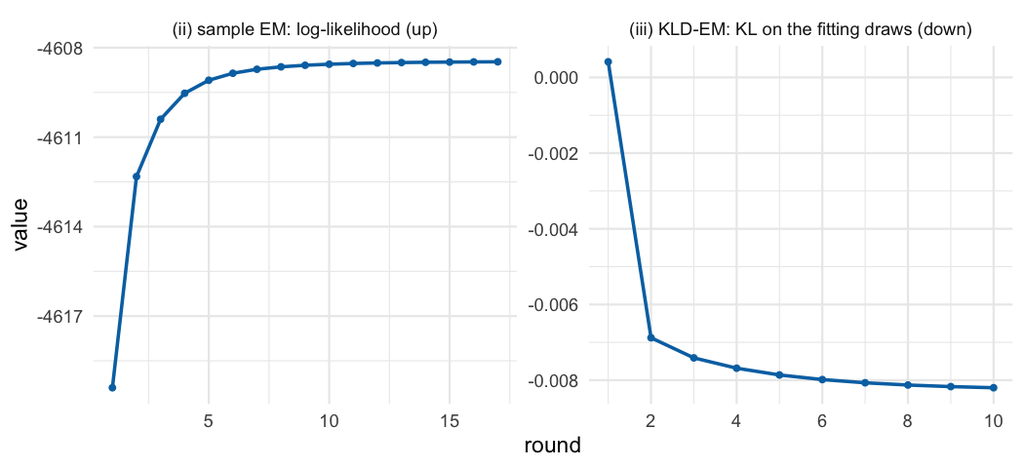

The value each method improves, round by round. Method (ii) raises the log-likelihood of the sample. Method (iii) lowers an estimate of the KL divergence, scored on the same trial points the fit was tuned to. That makes the estimate read low, and it can fall below zero, although a true KL divergence cannot.

```r
ggplot2::ggplot(trace_df, ggplot2::aes(iteration, value)) +
  ggplot2::geom_line(colour = "#0072B2", linewidth = 0.8) +
  ggplot2::geom_point(colour = "#0072B2", size = 1.1) +
  ggplot2::facet_wrap(~ panel, scales = "free") +
  ggplot2::scale_x_continuous(breaks = function(lim) unique(floor(pretty(lim)))) +
  ggplot2::labs(x = "round", y = "value") +
  ggplot2::theme_minimal(base_size = 11)
```

### One normal distribution fitted two ways, against the exact answer

With one component, methods (i) and (iii) aim at the same answer: the mean and covariance of the target. Method (i) reads them from the sample. Method (iii) reads only the formula. The banana target makes it possible to check both against the exact answer. It is built from two independent standard normal variables $z_1$ and $z_2$ as $x_1 = z_1$ and $x_2 = z_2 + (z_1^2 - 1)/2$. Its mean is therefore $(0, 0)$. The variance of $x_1$ is 1, the variance of $x_2$ is $1 + 2/4 = 3/2$, and the trace of the covariance, the sum of the two variances, is exactly $5/2$.

```r
banana <- banana_target(with_samples = TRUE, n = 2000L, seed = 1L)
m_b <- fit_proxymix(banana, N = 1L, regime = "moment")
k_b <- fit_proxymix(banana, N = 1L, regime = "kld",
                    proposal = proposal_mvt(n_dim = 2L,
                                            sigma = 4 * diag(2),
                                            df = 5),
                    is_size = 3000L, max_iter = 50L, seed = 1L)
tr_of <- function(f) sum(diag(f@covariances[[1L]]))
sample_trace <- sum(diag(cov(banana@samples)))
exact_trace <- 1 + (1 + 2 * 0.5^2)
```

The single normal proxy for the banana target, fitted two ways. The error is the trace of the covariance minus its exact value, 5/2, so a negative error means the spread is understated.

| Source | Uses | Trace of covariance | Error |
| --- | --- | --- | --- |
| method (i), moment match | the sample | 2.678 | 0.178 |
| method (iii), KLD-EM | the formula | 2.448 | -0.052 |
| the attached sample | the sample | 2.678 | 0.178 |
| exact value | the construction of the target | 2.500 | 0.000 |

The sample and the trial points are each one random draw. Repeating both with fresh seeds shows how far each trace moves by chance.

```r
sample_traces <- vapply(seq_len(500L), function(s) {
  sum(diag(cov(banana_target(with_samples = TRUE, n = 2000L,
                             seed = s)@samples)))
}, numeric(1L))
kld_traces <- vapply(seq_len(100L), function(s) {
  tr_of(fit_proxymix(banana, N = 1L, regime = "kld",
                     proposal = proposal_mvt(n_dim = 2L,
                                             sigma = 4 * diag(2),
                                             df = 5),
                     is_size = 3000L, max_iter = 50L, seed = s))
}, numeric(1L))
spread <- data.frame(
  seeds = c(length(sample_traces), length(kld_traces)),
  mean = c(mean(sample_traces), mean(kld_traces)),
  sd = c(sd(sample_traces), sd(kld_traces)),
  row.names = c("trace of a 2000-point sample", "method (iii) trace")
)
round(spread, 3L)
```

```
#>                              seeds  mean    sd
#> trace of a 2000-point sample   500 2.496 0.085
#> method (iii) trace             100 2.488 0.073
```

### Comparison with mclust, mixtools and flexmix

The established packages `mclust`, `mixtools` and `flexmix` fit mixtures to samples, as method (ii) does. They do not fit a mixture to a formula alone, so they can check method (ii) but not method (iii). Two checks were run, and every package was given the number of components. The first uses the 272 eruptions of the Old Faithful geyser in R’s `faithful` data (Azzalini and Bowman, 1990): the length of each eruption and the waiting time to the next. Each package fitted a two-component mixture to a random half of the eruptions. Each fit was then scored by its held-out log-likelihood, the average log density it gives to the other half. Higher is better. The second check is a simulation of 300 datasets of 200 points and 300 datasets of 1,000 points, drawn from the three-component mixture used above. Each fit was scored by its KL divergence from the true mixture, computed on a fine grid. A fit whose divergence exceeded 0.1 was counted as a misfit. `mclust` (Scrucca et al., 2016) chose among its covariance shapes by the Bayesian information criterion (BIC), a score that balances fit against the number of parameters. `flexmix` (Leisch, 2004; Grün and Leisch, 2008) kept the best of five random starts, the number proxymix uses by default for method (ii) as well. One `mixtools` (Benaglia et al., 2009) fit to 1,000 points took 22 s, so `mixtools` was left out of the simulation.

Two-component fits to half of the Old Faithful eruptions, scored on the other half (higher is better), and three-component fits to 300 simulated datasets at each sample size, scored by the KL divergence from the true mixture (lower is better). A misfit is a fit with a divergence above 0.1, counted out of 300.

| Package | Old Faithful: held-out log-likelihood | Mean KL, 200 points | Mean KL, 1,000 points | Misfits, 200 points | Misfits, 1,000 points |
| --- | --- | --- | --- | --- | --- |
| proxymix, method (ii) | -4.312 | 0.0527 | 0.0092 | 15 | 0 |
| mclust | -4.318 | 0.0583 | 0.0117 | 7 | 0 |
| mixtools | -4.312 | not run | not run | not run | not run |
| flexmix | -4.308 | 0.0955 | 0.0647 | 108 | 80 |

On this one split of Old Faithful, the four fits are within 0.011 of each other in held-out log-likelihood. In the simulation, proxymix had the lowest mean KL divergence of the three packages at both sample sizes. Its paired difference from `mclust` over the same datasets was -0.0056 at 200 points and -0.0026 at 1,000 points, with standard errors of 0.0011 and 0.0003. At 200 points, however, `mclust` had fewer misfits than proxymix, 7 against 15. At 1,000 points neither had any. `flexmix` produced misfits in 36 per cent of the 200-point datasets and 27 per cent of the 1,000-point ones.

At 200 points, proxymix took 0.023 s per fit on average, 2.4 times as long as `mclust` (0.010 s), and `flexmix` took 0.36 s. At 1,000 points, proxymix took 0.05 s, `mclust` 0.14 s and `flexmix` 0.52 s.

The code below runs the Old Faithful check with all four packages. It converts each package’s fit to a proxymix mixture, so that `dgmm()` scores every fit in the same way. It needs `mclust`, `mixtools` and `flexmix`, all on CRAN, and it is not run when this vignette is built.

```r
library(proxymix)
library(mclust)
library(mixtools)
library(flexmix)

# split the Old Faithful eruptions into a training half and a held-out half
faithful_mat <- as.matrix(datasets::faithful)
set.seed(20260925)
i_train <- sort(sample.int(nrow(faithful_mat), nrow(faithful_mat) / 2L))
train <- faithful_mat[i_train, ]
test <- faithful_mat[-i_train, ]
train_df <- data.frame(eruptions = train[, 1L], waiting = train[, 2L])

# convert each package's fit to a proxymix mixture, so dgmm() scores all four
as_gmm_mclust <- function(fit) {
  gmm(
    weights = fit$parameters$pro,
    means = lapply(seq_len(fit$G), function(k) fit$parameters$mean[, k]),
    covariances = lapply(seq_len(fit$G), function(k) {
      fit$parameters$variance$sigma[, , k]
    })
  )
}
as_gmm_mixtools <- function(fit) {
  gmm(weights = fit$lambda, means = fit$mu, covariances = fit$sigma)
}
as_gmm_flexmix <- function(fit) {
  comps <- lapply(fit@components, function(cc) cc[[1L]]@parameters)
  gmm(
    weights = prior(fit),
    means = lapply(comps, function(p) unname(p$center)),
    covariances = lapply(comps, function(p) unname(p$cov))
  )
}

# two-component fits to the training half
set.seed(1L)
fits <- list(
  proxymix = fit_proxymix(gmm_target_from_samples(train), N = 2L,
                          regime = "sample"),
  mclust = as_gmm_mclust(Mclust(train, G = 2L, verbose = FALSE)),
  mixtools = as_gmm_mixtools(mvnormalmixEM(train, k = 2L, verb = FALSE)),
  flexmix = as_gmm_flexmix(stepFlexmix(
    cbind(eruptions, waiting) ~ 1, data = train_df, k = 2L, nrep = 5L,
    model = FLXMCmvnorm(diagonal = FALSE), verbose = FALSE
  ))
)

# mean log-likelihood of the held-out eruptions under each fit
vapply(fits, function(g) mean(dgmm(test, g, log = TRUE)), numeric(1L))
```

The [extended version of this article](https://max578.github.io/proxymix/articles/extended/three_regimes.html) gives the full simulation code and a measure of how well each package’s grouping of the points matches the true components. It also compares method (iii) on the Old Faithful data with drawing a sample by Markov chain Monte Carlo, a standard way to sample from a formula, and fitting a mixture to that sample.

## Interpretation

Method (i) copies the moments of the sample rather than estimating them by iteration. Its fitted mean equals the sample mean exactly. Its fitted covariance differs from the sample covariance by $10^{-6}$, which is the constant that `ridge_eps` adds to the diagonal. Without that constant, the fitted covariance equals the sample covariance exactly.

Methods (ii) and (iii) reach nearly the same mixture by different routes. Method (ii) took 17 rounds and method (iii) took 10. Their component weights agree to within 0.015. Both put one component on each peak, which is correct for a target that is itself a mixture of three normal distributions. The 3,000 weighted trial points of method (iii) were worth 758 equally weighted points, 25 per cent of the total. On 30,000 fresh trial points, the KL divergence of the method (iii) proxy from the target is 0.012, with a simulation standard error of 0.002.

On the banana target, the attached sample overstates the exact trace of 2.5 by 0.178, and method (i) copies that error. Method (iii) never sees the sample. Its trace is 0.052 below the exact value. In this one run, method (iii) is therefore closer. The repeated draws show that this is partly chance. The trace of a 2,000-point sample has a standard deviation of 0.085, so this sample’s error is 2.1 standard deviations. The method (iii) trace has a standard deviation of 0.073 over 100 seeds, which is similar. Its average is 0.012 below the exact value, which is less than two standard errors of that average.

Methods (i) and (ii) fit whatever sample was drawn, while method (iii) fits the formula itself. With a large sample the difference is negligible. In the simulation above, method (iii) was also given the true formula and 3,000 trial points. It does not use the sample. Its mean KL divergence was 0.0068 and 0.0070 in the two halves of the simulation, which differ only by chance. Method (ii) reached 0.0527 and 0.0092. When samples are plentiful, method (iii) costs more: it needs a proposal, it evaluated the formula 33,000 times for the three-peak fit, and its weights have to be checked before the fit is used.

## Limitations

The number of components was set by hand in every fit, and the three-peak target was chosen because the right number is known. On a real target, `bic_aic()` and `select_N()` choose it. Too few components show up as a KL divergence that more trial points do not reduce.

The three-peak target is itself a mixture of three normal distributions, so methods (ii) and (iii) can both match it exactly. On a target of a different shape, the two methods aim at different quantities, and their fits differ.

The exact trace of the banana target is known only because the target is built from normal variables. A sum over a grid of 400 by 400 points on $[-8, 8]^2$ misses $6.4 \times 10^{-5}$ of the probability and gives 2.494, which is 0.006 below the exact value. The missing probability lies far out in the tail of $x_2$, where it adds much to the variance. A grid sum is a useful check only in two or three variables, and only after you have checked how much probability the grid misses.

The comparison with other packages covers one real dataset and one simulated mixture in two variables, with the number of components given. It does not cover a target of a different shape, a chosen number of components or more variables.

## Further reading

*Fitting a proxy to a density you cannot sample* introduces method (iii) and the fit certificate that checks it.

*How well a mixture proxies four awkward shapes* applies method (iii) to targets that are not Gaussian mixtures.

*Reading the entropy of a fitted mixture* covers choosing the number of components, including a method that finds the number rather than being given it.

*One mixture, many methods* shows what else a single fitted mixture can do.

*Mapping the optima of an objective* applies method (iii) to a function that is to be optimised, and returns a mixture with one component on each of its optima.

## References

Azzalini, A. and Bowman, A. W. (1990). *A look at some data on the Old Faithful geyser.* Journal of the Royal Statistical Society, Series C (Applied Statistics) 39(3), 357–365. https://doi.org/10.2307/2347385.

Benaglia, T., Chauveau, D., Hunter, D. R. and Young, D. S. (2009). *mixtools: An R package for analyzing finite mixture models.* Journal of Statistical Software 32(6), 1–29. https://doi.org/10.18637/jss.v032.i06.

Grün, B. and Leisch, F. (2008). *FlexMix version 2: Finite mixtures with concomitant variables and varying and constant parameters.* Journal of Statistical Software 28(4), 1–35. https://doi.org/10.18637/jss.v028.i04.

Hoek, J. van der and Elliott, R. J. (2024). *Mixtures of multivariate Gaussians.* Stochastic Analysis and Applications. https://doi.org/10.1080/07362994.2024.2372605.

Leisch, F. (2004). *FlexMix: A general framework for finite mixture models and latent class regression in R.* Journal of Statistical Software 11(8), 1–18. https://doi.org/10.18637/jss.v011.i08.

Scrucca, L., Fop, M., Murphy, T. B. and Raftery, A. E. (2016). *mclust 5: Clustering, classification and density estimation using Gaussian finite mixture models.* The R Journal 8(1), 289–317. https://doi.org/10.32614/RJ-2016-021.

## Reproduce

The target’s sample is drawn with `seed = 1L`, and each fit that uses random numbers is given `seed = 1L`. The repeated banana draws use seeds 1 to 500 for the samples and 1 to 100 for the trial points. The comparison is read from stored results. The simulation ran under proxymix 0.17.0, `mclust` 6.1.3 and `flexmix` 2.3-21, and took about 8 minutes on one core. The Old Faithful fits ran under `mixtools` 2.0.0.1 and the same versions of the other packages.